# **Introduction to mixed models with `R`**

**Note:** `Orthodont` is a `groupedData` object, and by default, the random effects have the same form as the fixed effects:

```r
# Ages are centered at 11 years
ortho1<-lme(distance~I(age-11),random= ~I(age-11) | Subject,data=Orthodont)
```

One of the questions of interest is whether boys and girls have different growth patterns.

```r
ortho2 <- update(ortho1,fixed = distance~Sex*I(age-11))
```

And use the `anova` function to compare both models:

```r
ortho1.ml <- update(ortho1,method="ML")
ortho2.ml <- update(ortho2,method="ML")
anova(ortho1.ml,ortho2.ml)
```

```
##           Model df      AIC      BIC    logLik   Test  L.Ratio p-value
## ortho1.ml     1  6 451.2116 467.3044 -219.6058
## ortho2.ml     2  8 443.8060 465.2630 -213.9030 1 vs 2 11.40565  0.0033
```

```r
ortho4 <- lme(distance ~ Sex+age, random=pdDiag(~I(age-11)),
              data=Orthodont, method="ML")
anova(ortho2.ml,ortho4)
```

```
##           Model df     AIC      BIC    logLik   Test  L.Ratio p-value
## ortho2.ml     1  8 443.806 465.2630 -213.9030
## ortho4        2  6 445.117 461.2098 -216.5585 1 vs 2 5.311018  0.0703
```

```r
ortho3 <- update(ortho2.ml,method="REML")
summary(ortho3)
```

```
## Linear mixed-effects model fit by REML
##  Data: Orthodont
##        AIC      BIC    logLik
##   448.5817 469.7368 -216.2908
##
## Random effects:
##  Formula: ~I(age - 11) | Subject
##  Structure: General positive-definite, Log-Cholesky parametrization
##             StdDev    Corr
## (Intercept) 1.8303267 (Intr)
## I(age - 11) 0.1803453 0.206
## Residual    1.3100397
##
## Fixed effects: distance ~ Sex + I(age - 11) + Sex:I(age - 11)
##                           Value Std.Error DF  t-value p-value
## (Intercept)           24.968750 0.4860007 79 51.37596  0.0000
## SexFemale             -2.321023 0.7614167 25 -3.04829  0.0054
## I(age - 11)            0.784375 0.0859995 79  9.12069  0.0000
## SexFemale:I(age - 11) -0.304830 0.1347353 79 -2.26243  0.0264
##  Correlation:
##                       (Intr) SexFml I(-11)
## SexFemale             -0.638
## I(age - 11)            0.102 -0.065
## SexFemale:I(age - 11) -0.065  0.102 -0.638
##
## Standardized Within-Group Residuals:
##         Min          Q1         Med          Q3         Max
## -3.16807863 -0.38593916  0.00710392  0.44515472  3.84946317
##
## Number of Observations: 108
## Number of Groups: 27
```

The next Figure shows that the variability in the orthodontic distance measurements is greater among boys than among girls. Within each gender the variability seems to be constant. There are few outlying observations for subjects `M09` and `M13`.

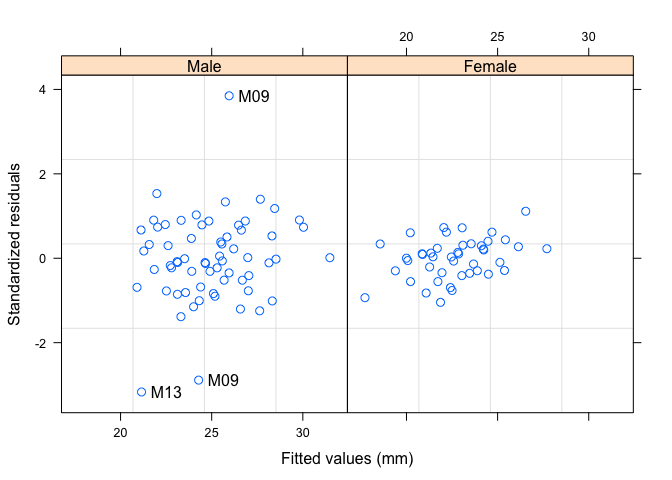

Scatterplots of standardized residuals versus fitted values for `ortho3`

```r
  plot(ortho3,resid(.,type="p")~fitted(.)|Sex, id=0.05, adj=-0.3)
```

A more general model to represent the orthodontic growth data allows different variances by gender for the within-group error. The `lme` function allow the modelling of heteroscedasticity of the within-error group via `weights` argument.

```r
ortho5 = update(ortho3,weights=varIdent(form = ~1|Sex))
ortho5
```

```
## Linear mixed-effects model fit by REML
##   Data: Orthodont
##   Log-restricted-likelihood: -205.7612
##   Fixed: distance ~ Sex + I(age - 11) + Sex:I(age - 11)
##           (Intercept)             SexFemale           I(age - 11)
##            24.9687500            -2.3210227             0.7843750
## SexFemale:I(age - 11)
##            -0.3048295
##
## Random effects:
##  Formula: ~I(age - 11) | Subject
##  Structure: General positive-definite, Log-Cholesky parametrization
##             StdDev   Corr
## (Intercept) 1.854979 (Intr)
## I(age - 11) 0.156517 0.394
## Residual    1.629585
##
## Variance function:
##  Structure: Different standard deviations per stratum
##  Formula: ~1 | Sex
##  Parameter estimates:
##      Male    Female
## 1.0000000 0.4088464
## Number of Observations: 108
## Number of Groups: 27
```

The parameters for `varIdent` give the ratio of the stratum standard errors to the within-group standard error. To allow identifiability, we assume $Var(\epsilon_{ij}) = \sigma^2 \theta_{s_{ij}}^2$ where $\theta_{s_{ij}}^2$ is the ratio between each variance and the one for the first stratum, i.e.: $\hat{\sigma}_{boys} = 1.6296 \quad \hat{\sigma}_{girls} = 1.6296\times 0.408 = 0.665$ The next Figure shows the scatter plots of the residuals of the heteroscedastic model `ortho5`.

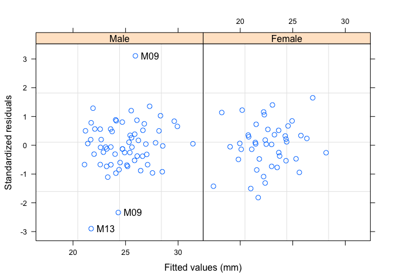

*Scatterplots of standardized residuals versus fitted values for `ortho5`*

```r
  plot(ortho5,resid(.,type="p")~fitted(.)|Sex, id=0.05, adj=-0.3)
```

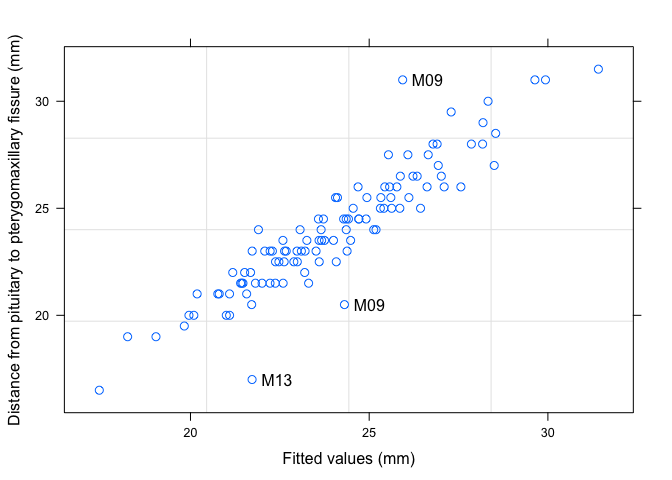

*Observed versus fitted values for `ortho5`*

```r
  plot(ortho5,distance~fitted(.), id=0.05, adj=-0.3)
```

The need of the heteroscedastic model can be formally tested with the `anova` method:

```r
anova(ortho3,ortho5)
```

```
##        Model df      AIC      BIC    logLik   Test  L.Ratio p-value
## ortho3     1  8 448.5817 469.7368 -216.2908
## ortho5     2  9 429.5225 453.3220 -205.7612 1 vs 2 21.05918  <.0001
```

The small p-value of the LRT statistic confirms that the heteroscedastic model explains better the orthodontic growth data. The assumption of normality for the within-group errors can be assessed with the normal probability plot of the residuals:

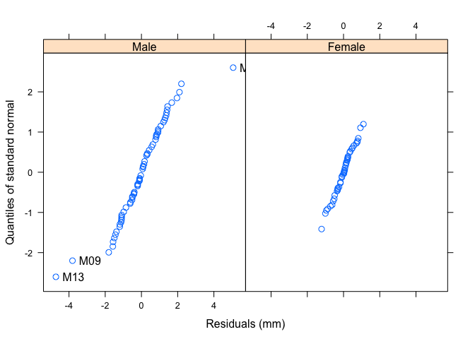

```r
  qqnorm(ortho5,~resid(.)|Sex, id=0.05, adj=-0.3)
```

## 6.2 Correlation

Correlation strcutures are used to model dependence among observations. In the context of mixed-effects models and extended linear models, they are used to model dependence among the within-group errors. To establish a general framework for correlation structures, we assume that the within-group errors $\epsilon_{ij}$ are associated with position vectors $\boldsymbol{p}_{ij},\boldsymbol{p}_{ij\prime}$, only through some distance between them, say $d(\boldsymbol{p}_{ij},\boldsymbol{p}_{ij\prime})$, and not with the particular values they assume. The general within-group correlation structure for single-level grouping is $\mathrm{Corr}(\boldsymbol{\epsilon}_{ij},\boldsymbol{\epsilon}_{ij\prime}) = h\left[d(\boldsymbol{p}_{ij},\boldsymbol{p}_{ij\prime}),\boldsymbol{\rho}\right],$ where

- *$\boldsymbol{\rho}$* is a vector of correlation parameters
- *$h(~)$* a known correlation function taking values between $-1$ and $1$, assumed continuous in $\boldsymbol{\rho}$, and such that $h(0,\boldsymbol{\rho})=1$, that is, if two observations have identical position vectors, they are the same observation and therefore have correlation 1.
- *$\boldsymbol{p}_{ij},\boldsymbol{p}_{ij\prime}$* position of the observations $y_{ij},y_{ik}$
- *$d(~)$* a known distance function.

### 6.2.1 Serial correlation structures

- `corAR1` This class implements an autoregressive correlation structure of orden 1. The argument `value` initializes the single correlation parameter $\phi$, which takes values between $-1$ and $1$, and by default is set to $0$. The position variable must evaluate to an integer vector, with non-repeated values per group, but its values are not required to be consecutive, so that missing time points are naturally accommodated. $Corr(\epsilon_{ij},\epsilon_{ik})=\rho^{|i-j|}$ For instance, for $t=5$: $corr(\boldsymbol{\epsilon}_i)=\left ( \begin{array}{ccccc} 1& \rho &\rho^2 &\rho^3 &\rho^4 \\ & 1& \rho &\rho^2 &\rho^3 \\ &&1&\rho &\rho^2 \\ &&&1 & \rho\\ &&&& 1 \end{array} \right )$

```r
cs1AR1 <- corAR1(0.8,form=~1|Subject)
cs1AR1 <- Initialize(cs1AR1,data=Orthodont)
corMatrix(cs1AR1)
```

- `corCAR1` This class implements the continious time $AR(1)$ structure. Its arguments are defined as in `corAR1`, but the position variable can be any continuous variable with non-repeated values per group and the correlation parameter $\phi$ can only take positive values.
- `corARMA`. This class is used to specify *Autorregressive-moving average* $ARMA(p,q)$ processes.

```r
 cs1ARMA <- corARMA(0.4,form=~1|Subject,q=1)
 cs1ARMA <- Initialize(cs1ARMA,data=Orthodont)
corMatrix(cs1ARMA)

 cs2ARMA <- corARMA(c(0.8,0.4),form=~1|Subject,p=1,q=1)
 cs2ARMA <- Initialize(cs2ARMA,data=Orthodont)
corMatrix(cs2ARMA)
```

- `corCompSymm` This class implements the compound symmetry correlation structure. The argument `value` is used to initialize the intraclass correlation coefficient, assuming a default value of $0$. Because the compound symmetry correlation model does not depend on the position of the observation, but just on the group to which it belongs, the `form` argument is used only to specify the grouping structure.

$Corr(\epsilon_{ij},\epsilon_{ik})= \left \{ \begin{array}{ll} 1 & \text{ if } j=k \\ \rho& \text{ if } j\neq k \end{array} \right .$

For example,

```r
 cs1CompSymm <- corCompSymm(value=0.3,form=~1|Subject)
 cs1CompSymm <- Initialize(cs1CompSymm,data=Orthodont)
corMatrix(cs1CompSymm)
```

specifies a compound symmetry structure with intraclass correlation of $0,3$ and grouping defined by `Subject`. By default, `form=~1`, implying that all observations belong to the same group.

- `corSymm` This class implements the general correlation structure. The argument `value` is used to initialize the correlation parameters, being given as a numeric vector with the lower diagonal elements of the largest correlation matrix represented by the `corSymm` object stacked columnwise.

$corr(\boldsymbol{\epsilon}_i)=\left ( \begin{array}{ccccc} 1& \rho &\rho_2 &\rho_3 &\rho_4 \\ & 1& \rho_5 &\rho_6 &\rho_7 \\ &&1&\rho_8 &\rho_9 \\ &&&1&\rho_{10}\\ &&&& 1 \end{array} \right )$

For example,

```r
cs1Symm <- corSymm(value=c(0.2,0.1,-0.1,0,0.2,0),form=~1|Subject)
cs1Symm <- Initialize(cs1Symm, data=Orthodont)
corMatrix(cs1Symm)
```

- `corExp` This class implements an exponential spatial correlation structure. The argument `value` is used to specify values for the range $\rho$, $Corr(\epsilon_{ij},\epsilon_{ik})= exp(-s/\rho) \quad s=d(p_{ij},p_{ik})$

**Example: Ovary data**

The data are collected from a study of the number of ovarian follicles larger than 10mm in diameter detected in 11 different mares (*female horses*) at several times in their estrus cycles. The data were recorded daily from three days before ovulation until three days after the next ovulation. The measurement times for each mare are scaled so that the ovulations for each mare occur at times 0 and 1.

```r
data(Ovary) # see ?Ovary
```

The figure of the number of follicles versus time per mare, suggest a periodic behavior for the number of follicles over time.

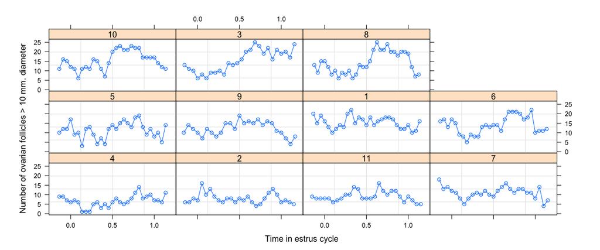

*Number of ovarian follicies greater than 10mm in diameter detected in mares at various times in their estrus cycles.*

```r
plot(Ovary)
```

A preliminar reasonable model for the number of follicles $y_{ij}$ for the $i$th mare at time $t_{ij}$:

$y_{ij} = (\beta_0 + u_{0i}) + (\beta_1 + u_{1i})\sin(2\pi t_{ij}) + \beta_2 \cos(2\pi t_{ij}) + \epsilon_{ij},$

where $\beta_0,\beta_1$ and $\beta_2$ are the fixed effects, $\boldsymbol{u}_i = \binom{u_{0i}}{u_{1i}}\sim \mathcal{N}(0,diag(\sigma_0^2,\sigma_1^2))$ is the random effects vector, assumed independent for different mares, and $\epsilon_{ij}$ is the within-group error, assumed independent for different $i,j$ and independent of the random effects. The random effects $u_{0i}$ and $u_{1i}$ are assumed to be independent with variances $\sigma_0^2$ and $\sigma_1^2$, respectively.

```r
ovary1 <- lme(follicles~sin(2*pi*Time) + cos(2*pi*Time), data=Ovary,
              random = pdDiag(~sin(2*pi*Time)))
ovary1
```

```
## Linear mixed-effects model fit by REML
##   Data: Ovary
##   Log-restricted-likelihood: -813.0409
##   Fixed: follicles ~ sin(2 * pi * Time) + cos(2 * pi * Time)
##        (Intercept) sin(2 * pi * Time) cos(2 * pi * Time)
##         12.1820241         -3.2985373         -0.8623725
##
## Random effects:
##  Formula: ~sin(2 * pi * Time) | Mare
##  Structure: Diagonal
##         (Intercept) sin(2 * pi * Time) Residual
## StdDev:    3.052136           2.079312 3.112854
##
## Number of Observations: 308
## Number of Groups: 11
```

```r
ovary2 <- lme(follicles~sin(2*pi*Time) + cos(2*pi*Time), data=Ovary,
              random = pdSymm(~sin(2*pi*Time))) # general positive-def ranef
ovary2
```

```
## Linear mixed-effects model fit by REML
##   Data: Ovary
##   Log-restricted-likelihood: -811.3405
##   Fixed: follicles ~ sin(2 * pi * Time) + cos(2 * pi * Time)
##        (Intercept) sin(2 * pi * Time) cos(2 * pi * Time)
##         12.1802616         -3.2992439         -0.8620191
##
## Random effects:
##  Formula: ~sin(2 * pi * Time) | Mare
##  Structure: General positive-definite
##                    StdDev   Corr
## (Intercept)        3.052574 (Intr)
## sin(2 * pi * Time) 2.082481 -0.592
## Residual           3.112607
##
## Number of Observations: 308
## Number of Groups: 11
```

```r
anova(ovary2,ovary1) # can we assume indepedent random effects for different mares
```

```
##        Model df      AIC      BIC    logLik   Test  L.Ratio p-value
## ovary2     1  7 1636.681 1662.723 -811.3405
## ovary1     2  6 1638.082 1660.404 -813.0409 1 vs 2 3.400713  0.0652
```

```r
                     # p-value is >0.05 Do not Reject H0 (correlation =0)
```

The `ACF` method obtains the empirical autocorrelation function from the residuals of an `lme` object:

```r
ACF(ovary1)
```

```
##    lag          ACF
## 1    0  1.000000000
## 2    1  0.379480128
## 3    2  0.179722025
## 4    3  0.035692749
## 5    4  0.059778881
## 6    5  0.002096953
## 7    6  0.064327101
## 8    7  0.071634861
## 9    8  0.048578247
## 10   9  0.027782488
## 11  10 -0.034275979
## 12  11 -0.077203767
## 13  12 -0.161131992
## 14  13 -0.196030197
## 15  14 -0.289337297
```

We can plot the empirical `ACF`, which shows significantly different from 0 at the first two lags, and decreases approximately exponentially for the first four lags.

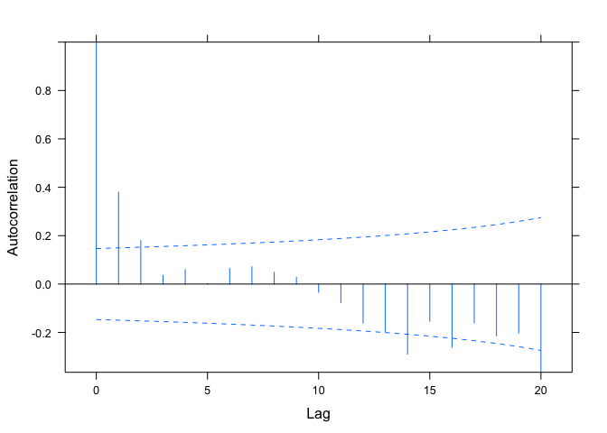

*Empirical autocorrelation function for the standard residuals of `ovary1` object.*

```r
plot(ACF(ovary1,maxLag=20),alpha=0.01)
```

This suggests an $AR(1)$ model may be suitable for the within-group correlation:

```r
ovary3 <- update(ovary2,correlation=corAR1())
ovary3
```

```
## Linear mixed-effects model fit by REML
##   Data: Ovary
##   Log-restricted-likelihood: -773.3439
##   Fixed: follicles ~ sin(2 * pi * Time) + cos(2 * pi * Time)
##        (Intercept) sin(2 * pi * Time) cos(2 * pi * Time)
##         12.1813088         -2.9900694         -0.8767559
##
## Random effects:
##  Formula: ~sin(2 * pi * Time) | Mare
##  Structure: General positive-definite
##                    StdDev   Corr
## (Intercept)        2.863130 (Intr)
## sin(2 * pi * Time) 1.278563 -0.837
## Residual           3.490714
##
## Correlation Structure: AR(1)
##  Formula: ~1 | Mare
##  Parameter estimate(s):
##       Phi
## 0.5673788
## Number of Observations: 308
## Number of Groups: 11
```

Because model `ovary2` is nested within `ovary3` (corresponding to $\phi=0$) we can compare them using a LRT

```r
anova(ovary2,ovary3)
```

```
##        Model df      AIC      BIC    logLik   Test  L.Ratio p-value
## ovary2     1  7 1636.681 1662.723 -811.3405
## ovary3     2  8 1562.688 1592.450 -773.3439 1 vs 2 75.99315  <.0001
```

The p-value $\approx 0$ indicates that $AR(1)$ model provides better fit than model with independent errors, suggesting that within-group serial correlation is present. Approximate confidence intervals of $\phi$ can be obtain as:

```r
intervals(ovary3)$corStruct
```

```
##        lower      est.     upper
## Phi 0.427705 0.5673788 0.6805904
## attr(,"label")
## [1] "Correlation structure:"
```

which consistently with the LRT results shows that $\phi$ is different from $0$.

The autocorrelation pattern shows in the residuals is also consistent with a $MA(2)$ model, in which only the two first lags have non-zero correlations.

```r
ovary4 <- update(ovary2,correlation=corARMA(q=2))
anova(ovary3,ovary4,test=FALSE)
```

```
##        Model df      AIC      BIC    logLik
## ovary3     1  8 1562.688 1592.450 -773.3439
## ovary4     2  9 1570.244 1603.726 -776.1218
```

Note that $AR(1)$ and $MA(2)$ are not nested, and therefore, cannot be compared through a LRT. They can however, be compared via their information criteria (the lower AIC/BIC the better). Hence $AR(1)$ is a better model.

An intermediate model between the $AR(1)$ and the $MA(2)$ models is the $ARMA(1,1)$ model. The $AR(1)$ model is nested within the $ARMA(1,1)$ model (corresponding to $\theta_1=0$) and we can use `anova` to compare both models through a LRT:

```r
ovary5 <- update(ovary2,correlation=corARMA(p=1,q=1))
anova(ovary3,ovary5)
```

```
##        Model df      AIC      BIC    logLik   Test  L.Ratio p-value
## ovary3     1  8 1562.688 1592.450 -773.3439
## ovary5     2  9 1559.354 1592.837 -770.6770 1 vs 2 5.333903  0.0209
```

The low p-value for the LRT indicates that the $ARMA(1,1)$ model provides a better fit to the data. The next Figure shows the empirical `ACF` of the $ARMA(1,1)$ model. No significant autocorrelations are observed, indicating that the normalized residuals behave like uncorrelated noise, as expected under the appropiate correlation model.

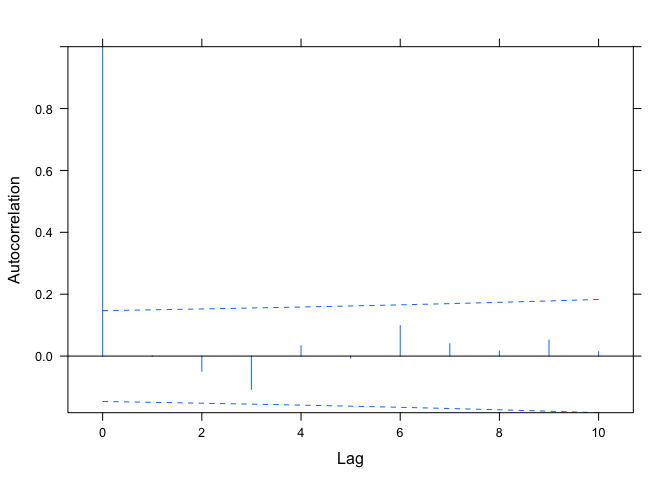

*Empirical autocorrelation function corresponding to the normalized residuals of model `ovary5`.*

```r
plot(ACF(ovary5, maxLag=10, resType="n"),alpha=0.01)
```

## 6.3 Non-gaussian responses: generalized linear mixed models

GLMM’s are an extension of generalized linear models (e.g., logistic regression) to include both fixed and random effects (hence mixed models). In a GLM: $\boldsymbol{\eta}=\boldsymbol{X}\boldsymbol{\beta} \Rightarrow \boldsymbol{\eta}=\boldsymbol{X}\boldsymbol{\beta}+\boldsymbol{Z}\boldsymbol{u}$ In a mixed model: $\boldsymbol{u}\sim N(0, \boldsymbol{G})\quad \boldsymbol{y}|\boldsymbol{u}\sim N(\boldsymbol{X}\boldsymbol{\beta}+\boldsymbol{Z}\boldsymbol{u}, \boldsymbol{R}) \Rightarrow \boldsymbol{y}|\boldsymbol{u}\sim B(m, p(\boldsymbol{u})); \ P(\lambda(\boldsymbol{u}))$

In order to fit the model, we need to compute the likelihood function of $\boldsymbol{y}$ which implies the calculus of an integral with no analytical solution. There are three ways to estimate a GLMM:

- Maximum likelihood (ML)
- Markov chain Montecarlo (MCMC) bayesian methods
- Generalized Estimating Equations (GEE)

We will focus on ML, where a numerical approximation is use to compute the integral (Laplace approximation or Gaussian quadrature).

In `R` the function to estimate a GLMM is `glmer` in library `lme4`, it works like funciona como `lmer`, but for we need to include the argument `family=` and `link` function, similarly to function `glm`.

**GLMMs for binary data: Bangladesh Demographic and Health Survey**

The data comes from the Bangladesh Demographic and Health Survey (BDHS), a nationally representative cross-sectional survey of women of reproductive age (13-49 years). Our response variable is a binary indicator of whether a woman received antenatal care from a medically-trained provider (a doctor, nurse or midwife) at least once before her most recent live birth. To minimise recall errors, the question was asked only about children born within five years of the survey. For this reason, our analysis sample is restricted to women wh o had a live birth in the five-year period before the survey. Note that if a woman had more than one live birth during the reference period, we consider only the most recent.

The data have a two-level hierarchical structure with 5366 women at level 1, nested within 361 communities at level 2. In rural areas a community corresponds to a village, while an urban community is a neighbourhood based on census definitions.

At level 1, we consider variables such as a woman’s age at the time of the birth and education. Level 2 variables include an indicator of whether the region of residence is classified as urban or rural. Explanatory variables are:

- `comm` Community identifier
- `wonid` Woman identifier
- `antemed` Received antenatal care at least once from a medically-trained provider, e.g. doctor, nurse or midwife (1 = yes, 0 = no)
- `bord` Birth order of child (ranges from 1 to 13)
- `mage` Mother’s age at the child’s birth (in years)
- `urban` Type of region of residence at survey (1=urban, 0=rural)
- `meduc` Mother’s level of education at survey (1=none, 2=primary, 3=secondary or higher)
- `slam` Mother’s religion (1=Islam, 0=other)
- `wealth` Household wealth index in quintiles (1=poorest to 5=richest)

In the case of a model with random intercept for Gaussian data, we have:

$E[y_{ij}|u_i]=\beta_0 +u_i+\epsilon_{ij} \quad u_i\sim N(0,\sigma^2_u) \quad \epsilon_{ij}\sim N(0, \sigma^2)$

The binary response variable (`antemed`) follows the command which is then followed by a `~` and then by a list of fixed part explanatory variables (excluding the constant as this is included by default). We will begin by fitting a model with only an intercept and community effects: $\mathrm{logit}(p_{ij})=\log\left ( \frac{p_{ij}}{1-p_{ij}}\right )=\beta_0 +u_{0j}$ The intercept $\beta_0$ is shared by all communities while the random effect $u_{oj}$ is specific to community $j$. The random effect is assumed to follow a normal distribution with variance $\sigma_{u_0}^2$.

```r
BDHS <- read.table("data/BDHS.txt", header = TRUE)
library(lme4)
fit <- glmer(antemed ~ (1 | comm), family = binomial("logit"), data = BDHS)
```

The above model contains only an intercept and so no fixed part explanatory variables are specified. The level 2 random part of the model is specified in brackets by the list of random part explanatory variables (the constant has to be explicitly specified by 1, followed by a single vertical bar `|` and then by the level 2 identifier (`comm`). The `family` option is used to specify a binomial distribution for the response with a logit link function. The data option specifies the dataframe being used to fit the model.

The estimation procedure optimizes a function of the log likelihood using penalized iteratively re-weighted least squares. The log-likelihood is evaluated using the Laplacian approximation.

```r
summary(fit)
```

```
## Generalized linear mixed model fit by maximum likelihood (Laplace
##   Approximation) [glmerMod]
##  Family: binomial  ( logit )
## Formula: antemed ~ (1 | comm)
##    Data: BDHS
##
##      AIC      BIC   logLik deviance df.resid
##   6639.5   6652.7  -3317.8   6635.5     5364
##
## Scaled residuals:
##     Min      1Q  Median      3Q     Max
## -2.7779 -0.7458  0.3423  0.7118  2.6784
##
## Random effects:
##  Groups Name        Variance Std.Dev.
##  comm   (Intercept) 1.464    1.21
## Number of obs: 5366, groups:  comm, 361
##
## Fixed effects:
##             Estimate Std. Error z value Pr(>|z|)
## (Intercept)  0.14809    0.07178   2.063   0.0391 *
## ---
## Signif. codes:  0 '***' 0.001 '**' 0.01 '*' 0.05 '.' 0.1 ' ' 1
```

From the model estimates (using Laplacian approximation), we can say that the log-odds of receiving antenatal care from a medically-trained provider in an community (one with $u_{0j}$) is estimated as $\hat{\beta}_0=0.148$. The intercept for community $j$ is $0.148+u_{0j}$, where the variance of $u_{0j}$ is estimated as $\hat{\sigma}_{0j}^2=1.464$.

The likelihood ratio statistic for testing the null hypothesis, that $\hat{\sigma}_{0j}^2=0$, can be calculated by comparing the two-level model, with the corresponding single-level model without the level 2 random effect.

```r
fit0 <- glm(antemed ~ 1, family=binomial("logit"),data=BDHS)
test = -2*logLik(fit0) + 2*logLik(fit)
mean(pchisq(test,df=c(0,1),lower.tail=FALSE))
```

```
## [1] 3.169612e-176
```

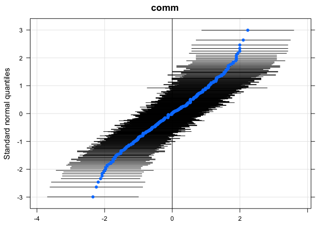

```r
library(lattice)
qqmath(ranef(fit, condVar=TRUE),strip=FALSE)$comm
```

Now we include maternal age (`mage`) as an explanatory variable in the model. First we center the covariate:

```r
BDHS$magec <- BDHS$mage - mean(BDHS$mage)
fit2 <- glmer(antemed~magec+(1|comm),family=binomial("logit"),data=BDHS)
summary(fit2)
```

```
## Generalized linear mixed model fit by maximum likelihood (Laplace
##   Approximation) [glmerMod]
##  Family: binomial  ( logit )
## Formula: antemed ~ magec + (1 | comm)
##    Data: BDHS
##
##      AIC      BIC   logLik deviance df.resid
##   6603.4   6623.2  -3298.7   6597.4     5363
##
## Scaled residuals:
##     Min      1Q  Median      3Q     Max
## -2.9757 -0.7431  0.3357  0.7190  3.2357
##
## Random effects:
##  Groups Name        Variance Std.Dev.
##  comm   (Intercept) 1.462    1.209
## Number of obs: 5366, groups:  comm, 361
##
## Fixed effects:
##              Estimate Std. Error z value Pr(>|z|)
## (Intercept)  0.144604   0.071781   2.015    0.044 *
## magec       -0.032357   0.005235  -6.181 6.37e-10 ***
## ---
## Signif. codes:  0 '***' 0.001 '**' 0.01 '*' 0.05 '.' 0.1 ' ' 1
##
## Correlation of Fixed Effects:
##       (Intr)
## magec 0.008
```

Note that there is little change in the estimate of the between-community variance, suggesting that the distribution of maternal age is similar across communities.

The equation of the average fitted regression line, expressing the relationship between the log-odds of receiving antenatal care and maternal age, is:

$\log\left ( \frac{\hat{p}_{ij}}{1-\hat p_{ij}}\right )=0.144-0.032 \mathrm{magec}_{ij}$

The fitted line for a given community will differ from the average line in its intercept, by an amount $\hat{u}_{j}$ for community $j$. A plot of the predicted community lines will therefore show a set of parallel lines.

```r
predprob <- fitted(fit2)
library(VGAM)
```

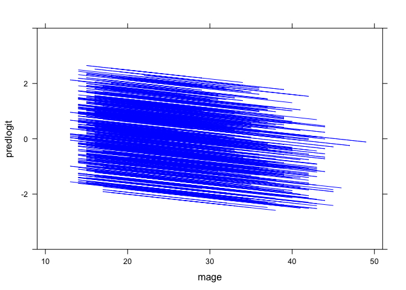

*Fitted values*

```r
predlogit <- logit(predprob)
datapred=unique(data.frame(cbind(predlogit = predlogit, comm = BDHS$comm,mage = BDHS$mage)))
xyplot(predlogit ~ mage, data = datapred, groups = comm, type = "l", col = "blue", xlim = c(9, 51), ylim = c(-4, 4))
```

Hence, for a woman of $22$ years the log-odds of receiving antenatal care ranges from about $-2.2$ to $2.5$ depending on which community she lives in. This translates to a range in probabilities of $exp(-2.2)/[1+exp(-2.2)]=0.10$ to $exp(-2.5)/[1+exp(-2.5)]=0.92$, so there are strong community effects.

Now, we include additional variables, such as `wealth` and `meduc`.

```r
BDHS$meduc <- factor(BDHS$meduc)
BDHS$wealthc <- BDHS$wealth-mean(BDHS$wealth) # we center wealth
fit3 <- glmer(antemed~magec+wealthc+meduc+(1|comm), family=binomial("logit"), data=BDHS)
summary(fit3)
```

```
## Generalized linear mixed model fit by maximum likelihood (Laplace
##   Approximation) [glmerMod]
##  Family: binomial  ( logit )
## Formula: antemed ~ magec + wealthc + meduc + (1 | comm)
##    Data: BDHS
##
##      AIC      BIC   logLik deviance df.resid
##   5993.5   6033.0  -2990.7   5981.5     5360
##
## Scaled residuals:
##     Min      1Q  Median      3Q     Max
## -3.4726 -0.6437  0.2581  0.6518  3.7138
##
## Random effects:
##  Groups Name        Variance Std.Dev.
##  comm   (Intercept) 0.8667   0.931
## Number of obs: 5366, groups:  comm, 361
##
## Fixed effects:
##              Estimate Std. Error z value Pr(>|z|)
## (Intercept) -0.490324   0.080317  -6.105 1.03e-09 ***
## magec       -0.005141   0.005722  -0.898    0.369
## wealthc      0.402697   0.030012  13.418  < 2e-16 ***
## meduc2       0.544514   0.085843   6.343 2.25e-10 ***
## meduc3       1.305071   0.099406  13.129  < 2e-16 ***
## ---
## Signif. codes:  0 '***' 0.001 '**' 0.01 '*' 0.05 '.' 0.1 ' ' 1
##
## Correlation of Fixed Effects:
##         (Intr) magec  welthc meduc2
## magec   -0.195
## wealthc  0.213 -0.105
## meduc2  -0.581  0.215 -0.178
## meduc3  -0.593  0.317 -0.376  0.554
```

**Variance Partition Coefficient**

The variance partition coefficient (VPC) is calculated as $\frac{\sigma^2_u}{\sigma^2_u + \sigma^2}$. From theory, the standard logistic distribution has variance $\sigma^2 = \pi^2/3 = 3.29$. Then with $\hat{\sigma}_u^2=0.8667$, $VPC = 0,868/(0,868+3,29) = 0.208$.

```r
# variance of r.e.
as.numeric(summary(fit3)$varcor)
```

```
## [1] 0.8667314
```

**Predict probabilities from a Multilevel model**

By substituing the mean of the Level 2 residuals ($u_j=0$) in the formula for the response probability: $p_{ij}=\frac{exp(z_{ij})}{1+exp(z_{ij})}$ where  
$z_{ij}=-0.491 -0.005\mathrm{magec}_{ij}+0.403\mathrm{wealthc}_{ij}+0.545\mathrm{meduc2}_{ij}+1.306\mathrm{meduc3}_{ij}$

The resulting predictions represent probabilities for the median community, and are sometimes referred to as predictions.

**Two-level random slope model**

In the previous model we assumed that the maternal age, education and household wealth are assumed to be the same in each community. We will now fit a random slope (coefficient) for wealth to allow its effect to vary across communities.

$\log\left( \frac{p_{ij}}{1-pi_{ij}}\right) = \beta_0 + \beta_1 \mathrm{magec}_{ij} + \beta_2 \mathrm{meduc}_{ij} + \beta_3 \mathrm{wealthc}_{ij} + u_{0j} + u_{4j}\mathrm{wealthc}_ij$ Note that the new term $u_{4j}$ has been added to the model, so that the coefficient of `wealthc` has become $\beta_{4j} = \beta_4 + u_{4j}$, and so the community-level variance has been replaced by a matrix with two new parameters, $\sigma_{u_4}^2$ and $\sigma_{u_{04}}$. The two community level residuals $\sigma_{0j}$ and $\sigma_{4j}$ are assumed to follow a bivariate normal distribution with mean vector $0$ and variance-covariance matrix $\begin{pmatrix} \sigma_{u_0}^2 & \\ \sigma_{u_{04}} & \sigma_{u_4}^2 \end{pmatrix}$

The model is fitted in `R`

```r
fit4 <- glmer(antemed~magec+meduc+wealthc+(1+wealthc|comm), data = BDHS, family=binomial("logit"))
summary(fit4)
```

```
## Generalized linear mixed model fit by maximum likelihood (Laplace
##   Approximation) [glmerMod]
##  Family: binomial  ( logit )
## Formula: antemed ~ magec + meduc + wealthc + (1 + wealthc | comm)
##    Data: BDHS
##
##      AIC      BIC   logLik deviance df.resid
##   5987.3   6040.0  -2985.7   5971.3     5358
##
## Scaled residuals:
##     Min      1Q  Median      3Q     Max
## -3.2754 -0.6513  0.2928  0.6409  4.3347
##
## Random effects:
##  Groups Name        Variance Std.Dev. Corr
##  comm   (Intercept) 0.84641  0.9200
##         wealthc     0.01399  0.1183   -1.00
## Number of obs: 5366, groups:  comm, 361
##
## Fixed effects:
##              Estimate Std. Error z value Pr(>|z|)
## (Intercept) -0.490825   0.079968  -6.138 8.37e-10 ***
## magec       -0.005163   0.005727  -0.902    0.367
## meduc2       0.541494   0.086211   6.281 3.36e-10 ***
## meduc3       1.299956   0.098867  13.149  < 2e-16 ***
## wealthc      0.408347   0.030908  13.212  < 2e-16 ***
## ---
## Signif. codes:  0 '***' 0.001 '**' 0.01 '*' 0.05 '.' 0.1 ' ' 1
##
## Correlation of Fixed Effects:
##         (Intr) magec  meduc2 meduc3
## magec   -0.194
## meduc2  -0.584  0.213
## meduc3  -0.592  0.315  0.558
## wealthc  0.042 -0.103 -0.174 -0.362
## convergence code: 0
## unable to evaluate scaled gradient
## Model failed to converge: degenerate  Hessian with 1 negative eigenvalues
```

Note, that we specified the random term `(1+wealthc|comm)` which implies that the random intercepts and slopes are correlated. Now we test if the intercept and the slops are independent, i.e. the null hypothesis is that the two new parameters $\sigma_{u_4}^2$ and $\sigma_{u_{04}}$ are simultaneously equal to zero.

```r
anova(fit3,fit4) # reject H0
```

```
## Data: BDHS
## Models:
## fit3: antemed ~ magec + wealthc + meduc + (1 | comm)
## fit4: antemed ~ magec + meduc + wealthc + (1 + wealthc | comm)
##      Df    AIC  BIC  logLik deviance Chisq Chi Df Pr(>Chisq)
## fit3  6 5993.5 6033 -2990.7   5981.5
## fit4  8 5987.3 6040 -2985.7   5971.3 10.14      2   0.006283 **
## ---
## Signif. codes:  0 '***' 0.001 '**' 0.01 '*' 0.05 '.' 0.1 ' ' 1
```

We therefore conclude that the effect of wealth does indeed vary across communities. The effect of wealth on the log-odds of receiving antenatal care in community $j$ is estimated as $0,408 + \hat{u}_{4j}$, and the between-community variance in the effect of wealth is estimated as $0.014$. Because `wealthc` has been centered about is sample mean, the intercept variance $\hat{\sigma}^2_{u0}=0,846$ is interpreted as the between-community variance in the log-odds of antenatal care at the mean of the wealth index. The negative intercept-slope covariance estimate ($\hat{\sigma}_{04}=0,92\times 0,1183\times-1,00=-0,110$) implies that communities with above-average antenatal care uptake (intercept residual $\hat{u}_{0j}>0$) tend also to have below-average effects of wealth (slope residual $\hat{u}_{4j}<0$). In other words, in those communities with a high level of antenatal care, it tends to decrease with wealth.

The equation for the fitted regression for community $j$, for a woman of mean age (`magec=0`), and no education (`meduc2=meduc3=0`) is:

$log \left ( \frac{p_{ij}}{1-p_{ij}} \right )=(-0.4908+\hat{u}_i)+(0.408+\hat{v}_i)\mathrm{weathc}_{ij}$ To obtain the fitted line of a woman with different ages or levels of education, only the intercept would change. For a woman with primary education, for example, the intercept would increase from $-0.4908$ to $-0.4908+0.5415=0.0507$.

We can include a Level 2 explanatory variable (e.g. `urban`)

```r
BDHS$urban <- factor(BDHS$urban)
levels(BDHS$urban) <- c("rural","urban")
fit5 <- glmer(antemed~magec+meduc+wealthc+urban+(1+wealthc|comm),
              data = BDHS, family=binomial("logit"))
summary(fit5)
```

```
## Generalized linear mixed model fit by maximum likelihood (Laplace
##   Approximation) [glmerMod]
##  Family: binomial  ( logit )
## Formula: antemed ~ magec + meduc + wealthc + urban + (1 + wealthc | comm)
##    Data: BDHS
##
##      AIC      BIC   logLik deviance df.resid
##   5911.7   5970.9  -2946.8   5893.7     5357
##
## Scaled residuals:
##     Min      1Q  Median      3Q     Max
## -3.6969 -0.6555  0.2729  0.6472  4.3840
##
## Random effects:
##  Groups Name        Variance Std.Dev. Corr
##  comm   (Intercept) 0.6491   0.8057
##         wealthc     0.0271   0.1646   -1.00
## Number of obs: 5366, groups:  comm, 361
##
## Fixed effects:
##              Estimate Std. Error z value Pr(>|z|)
## (Intercept) -0.863081   0.087340  -9.882  < 2e-16 ***
## magec       -0.004906   0.005731  -0.856    0.392
## meduc2       0.569354   0.086176   6.607 3.93e-11 ***
## meduc3       1.350763   0.098549  13.707  < 2e-16 ***
## wealthc      0.354832   0.031391  11.304  < 2e-16 ***
## urbanurban   1.032676   0.114230   9.040  < 2e-16 ***
## ---
## Signif. codes:  0 '***' 0.001 '**' 0.01 '*' 0.05 '.' 0.1 ' ' 1
##
## Correlation of Fixed Effects:
##            (Intr) magec  meduc2 meduc3 welthc
## magec      -0.185
## meduc2     -0.569  0.213
## meduc3     -0.593  0.315  0.560
## wealthc     0.105 -0.099 -0.170 -0.355
## urbanurban -0.480  0.020  0.075  0.121 -0.230
## convergence code: 0
## Model failed to converge with max|grad| = 0.0129444 (tol = 0.001, component 1)
```

**Deer data**

Source Zuur et al. (2009) et al. (page 326)

The analysis is focused on the relationship between the presence and absence of larvae in deer and the explanatory variables `length` and `sex` of the deer and the `Farm`. Instead of using farm as a fixed effect with 24 levels, we use it as a random effect and the model becomes $y_{ij} \sim Bin(1,p_{ij})$

$logit(p_{ij}) = \beta_0 + \beta_1 \mathrm{Length}_{ij} + u_i,\qquad u_i \sim \mathcal{N}(0,\sigma_u^2)$

$y_{ij}$ is 1 if deer $j$ of Farm $i$ is infected and 0 otherwise. The random intercept $u_i$ is assumed to be normally distributed with mean $0$ and variance $\sigma_u^2$. Using farm as a random intercept has another major advantage. A random intercept model is implicitly introducing the compound symmetrical correlation structure. This implies that the probability of a deer carrying the parasite is correlated to other deer on the same farm.

There are various functions in `R` that can be used for GLMM. The main ones are `glmmPQL` from the `MASS` package, `glmer` from the `lme4` package, and `glmmML` from the `glmmML` package.

```r
deer <- read.table('data/deer.txt',header=TRUE)
deer$Farm <- factor(deer$Farm)
```

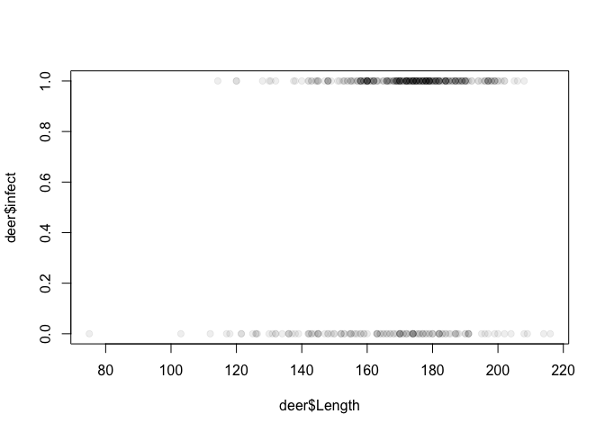

*Deer infection data*

```r
plot(deer$Length,deer$infect,col='#00000011', pch=19)
```

```r
deer.glm <- glm(infect~Length+Farm,data=deer,family=binomial)
library(lme4)
# use glmer() to fit GLMM.
#  Farm is a unique identifier for a cluster; does not need to be a factor
deer.glmm <- glmer(infect~Length+(1|Farm),data=deer,family=binomial)
deer.glmm2 <- update(deer.glmm,.~.-Length,data=deer)
anova(deer.glmm2,deer.glmm)
```

```
## Data: deer
## Models:
## deer.glmm2: infect ~ (1 | Farm)
## deer.glmm: infect ~ Length + (1 | Farm)
##            Df    AIC    BIC  logLik deviance  Chisq Chi Df Pr(>Chisq)
## deer.glmm2  2 464.26 472.46 -230.13   460.26
## deer.glmm   3 436.81 449.12 -215.41   430.81 29.442      1   5.76e-08 ***
## ---
## Signif. codes:  0 '***' 0.001 '**' 0.01 '*' 0.05 '.' 0.1 ' ' 1
```

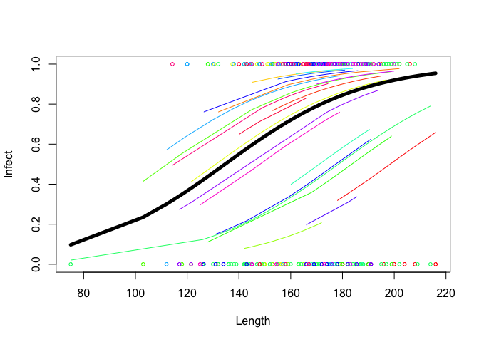

*GLMM predicted probabilities of parasitic infection. The thick line in the middle represents the predicted values for the ‘population of farms’*

Using `glmmPQL` and `glmmML`, note that the results may differ as the estimation procedure is different.

```r
library(MASS)
deer2 <- glmmPQL(infect ~ Length, random=~1|Farm,family=binomial("logit"),
                 data=deer)
summary(deer2)

library(glmmML) # similar to glmer
deer3 <- glmmML(infect ~ Length, cluster=Farm,family=binomial("logit"),
                data=deer)
summary(deer3)
```

References

Patterson, H. D., and R. Thompson. 1971. “Recovery of Inter-Block Information When Block Sizes Are Unequal.” *Biometrika* 58: 545–54.

Pinheiro, J. C., and D. M. Bates. 2000. *Mixed-Effects Models in S and S-PLUS*. Statistics and Computing. Springer-Verlag.

Searle, S.R., G. Casella, and C.E. McCulloch. 1992. *Variance Components*. Wiley Series in Probability; Mathematical Statistics.

Singer, J.D., and J.B. Willet. 2003. *Applied Longitudinal Data Analysis*. Oxford University Press.

Zuur, A, E.N. Ieno, N. Walker, A.A. Saveliev, and G.M. Smith. 2009. *Mixed Effects Models and Extensions in Ecology with R (Statistics for Biology and Health)*. Edited by M. H. Gail, K. Krickeberg, J. M. Samet, A. Tsiatis, and W. Wong. Statistics for Biology and Health. Springer.